# Introduction to statistical learning - Chapter 3

Joshua Malina

September 18, 2015

## Applied Problems

8. 1. Use the lm() function to perform a simple linear regression with mpg as the response and horsepower as the predictor. Use the summary() function to print the results.

```r
lmodel <- lm(mpg ~ horsepower, data=Auto)
summary(lmodel)
```

```
##
## Call:
## lm(formula = mpg ~ horsepower, data = Auto)
##
## Residuals:
##      Min       1Q   Median       3Q      Max
## -13.5710  -3.2592  -0.3435   2.7630  16.9240
##
## Coefficients:
##              Estimate Std. Error t value Pr(>|t|)
## (Intercept) 39.935861   0.717499   55.66   <2e-16 ***
## horsepower  -0.157845   0.006446  -24.49   <2e-16 ***
## ---
## Signif. codes:  0 '***' 0.001 '**' 0.01 '*' 0.05 '.' 0.1 ' ' 1
##
## Residual standard error: 4.906 on 390 degrees of freedom
## Multiple R-squared:  0.6059, Adjusted R-squared:  0.6049
## F-statistic: 599.7 on 1 and 390 DF,  p-value: < 2.2e-16
```

**i. Is there a relationship between the predictor and the re- sponse?**

Yes, the p-value for horsepower is very low (<2e-16). And since the coefficient is less than zero (-0.15), we can say that the relationship between predictor (horsepower) and response (mpg) is negative.

**ii. How strong is the relationship between the predictor and the response?**

Yes, the relationship is very strong, since the p-value is very low.

**iii. Is the relationship between the predictor and the response positive or negative?**

The relationship is negative.

**iv. What is the predicted mpg associated with a horsepower of 98? What are the associated 95 % confidence and prediction intervals?**

MPG when horsepower=98

```r
h <- data.frame(horsepower=98)
predict(lmodel, h)
```

```
##        1
## 24.46708
```

Confidence interval, 95%:

```r
predict(lmodel, h, interval="confidence")[1, 2:3]
```

```
##      lwr      upr
## 23.97308 24.96108
```

Prediction interval, 95%

```r
predict(lmodel, h, interval="predict")[1, 2:3]
```

```
##      lwr      upr
## 14.80940 34.12476
```

2. Plot the response and the predictor. Use the abline() function to display the least squares regression line.

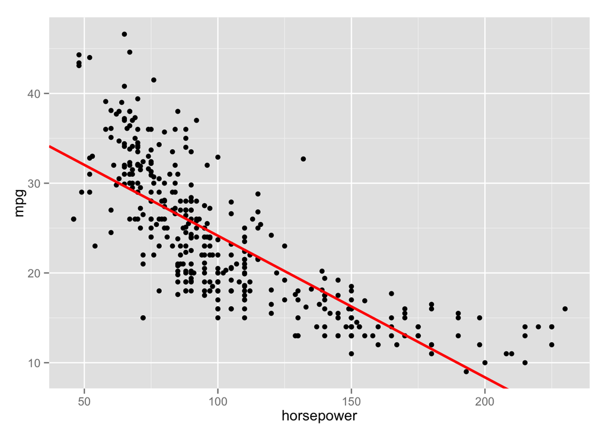

```r
c = coef(lmodel)
ggplot(data=Auto, aes(horsepower, mpg)) + geom_point() + geom_abline(aes(intercept=c[1], slope=c[2]), color="red", size=1)
```

3. Use the plot() function to produce diagnostic plots of the least squares regression fit. Comment on any problems you see with the fit.

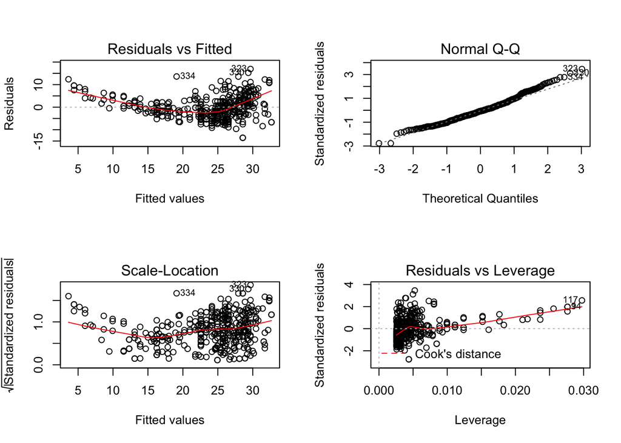

```r
par(mfrow=c(2,2))
plot(lmodel)
```

It looks like there is some non-linear trend that is not captured in the model, as per the residual vs fitted plot. In the residuals vs leverage plot, it seems that there may be a few points that have high leverage.

9. 1. Produce a scatterplot matrix which includes all of the variables in the data set.

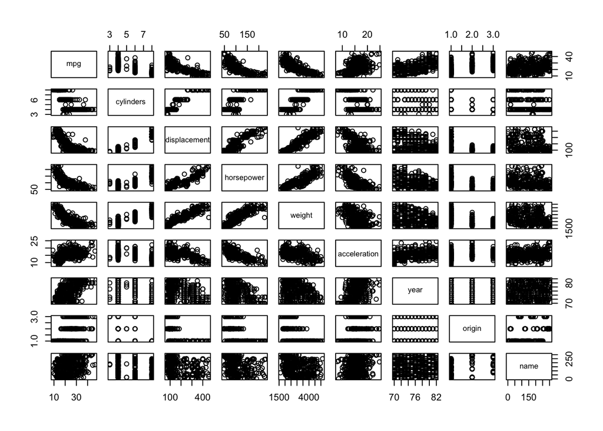

```r
pairs(Auto)
```

2. Compute the matrix of correlations between the variables using the function cor(). You will need to exclude the name variable, which is qualitative.

```r
exclude_names = data.frame(Auto[,-9])
cor(exclude_names)
```

```
##                     mpg  cylinders displacement horsepower     weight
## mpg           1.0000000 -0.7776175   -0.8051269 -0.7784268 -0.8322442
## cylinders    -0.7776175  1.0000000    0.9508233  0.8429834  0.8975273
## displacement -0.8051269  0.9508233    1.0000000  0.8972570  0.9329944
## horsepower   -0.7784268  0.8429834    0.8972570  1.0000000  0.8645377
## weight       -0.8322442  0.8975273    0.9329944  0.8645377  1.0000000
## acceleration  0.4233285 -0.5046834   -0.5438005 -0.6891955 -0.4168392
## year          0.5805410 -0.3456474   -0.3698552 -0.4163615 -0.3091199
## origin        0.5652088 -0.5689316   -0.6145351 -0.4551715 -0.5850054
##              acceleration       year     origin
## mpg             0.4233285  0.5805410  0.5652088
## cylinders      -0.5046834 -0.3456474 -0.5689316
## displacement   -0.5438005 -0.3698552 -0.6145351
## horsepower     -0.6891955 -0.4163615 -0.4551715
## weight         -0.4168392 -0.3091199 -0.5850054
## acceleration    1.0000000  0.2903161  0.2127458
## year            0.2903161  1.0000000  0.1815277
## origin          0.2127458  0.1815277  1.0000000
```

3. Use the lm() function to perform a multiple linear regression with mpg as the response and all other variables except name as the predictors. Use the summary() function to print the results.

```r
nmodel <- lm(data=Auto, mpg~.-name) ; summary(nmodel)
```

```
##
## Call:
## lm(formula = mpg ~ . - name, data = Auto)
##
## Residuals:
##     Min      1Q  Median      3Q     Max
## -9.5903 -2.1565 -0.1169  1.8690 13.0604
##
## Coefficients:
##                Estimate Std. Error t value Pr(>|t|)
## (Intercept)  -17.218435   4.644294  -3.707  0.00024 ***
## cylinders     -0.493376   0.323282  -1.526  0.12780
## displacement   0.019896   0.007515   2.647  0.00844 **
## horsepower    -0.016951   0.013787  -1.230  0.21963
## weight        -0.006474   0.000652  -9.929  < 2e-16 ***
## acceleration   0.080576   0.098845   0.815  0.41548
## year           0.750773   0.050973  14.729  < 2e-16 ***
## origin         1.426141   0.278136   5.127 4.67e-07 ***
## ---
## Signif. codes:  0 '***' 0.001 '**' 0.01 '*' 0.05 '.' 0.1 ' ' 1
##
## Residual standard error: 3.328 on 384 degrees of freedom
## Multiple R-squared:  0.8215, Adjusted R-squared:  0.8182
## F-statistic: 252.4 on 7 and 384 DF,  p-value: < 2.2e-16
```

**i. Is there a relationship between the predictors and the re- sponse?**

Yes, the overall p-vale is < 2.2e-16

**ii. Which predictors appear to have a statistically significant relationship to the response?**

Displacement, weight, year and origin are all statistically signficant predictors of mpg.

**iii. What does the coefficient for the year variable suggest?**

**d) Use the plot() function to produce diagnostic plots of the linear regression fit. Comment on any problems you see with the fit. Do the residual plots suggest any unusually large outliers? Does the leverage plot identify any observations with unusually high leverage?**

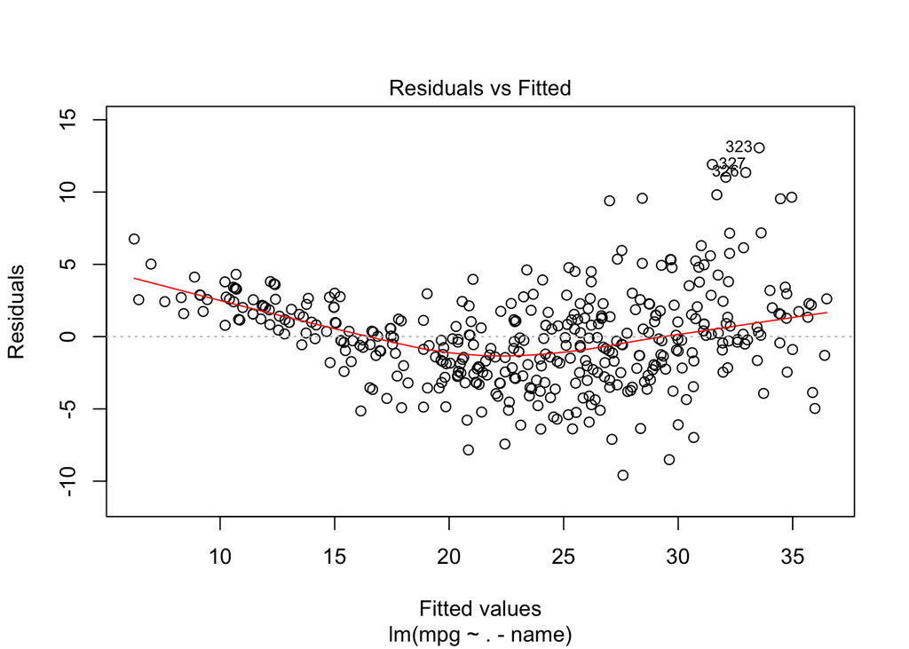

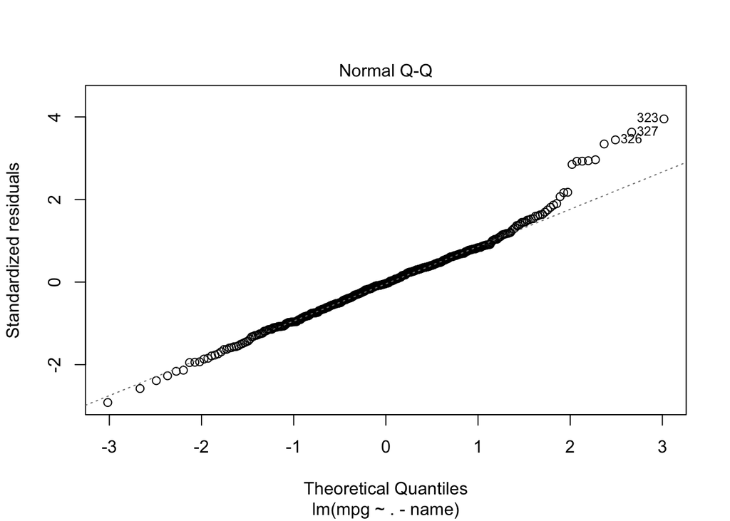

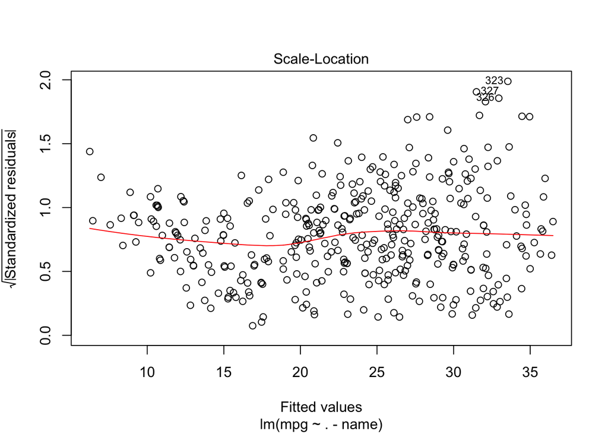

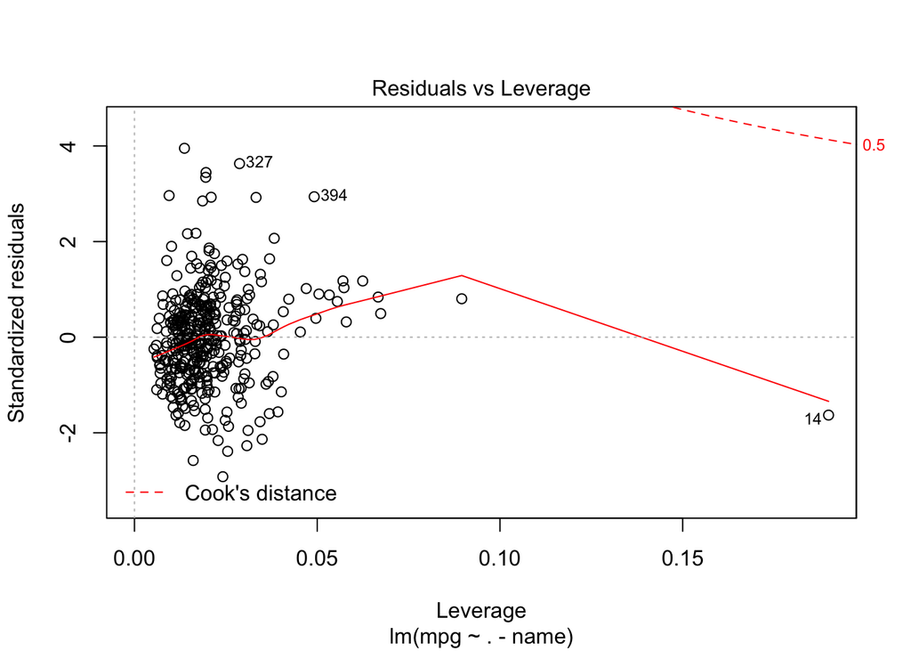

```r
plot(nmodel)
```

Indeed, there appears to be a non-linearlity that is not captured by the model, and further, the point “14” seems to have a lot of leverage.

**(e) Use the * and : symbols to fit linear regression models with interaction effects. Do any interactions appear to be statistically significant?**

```r
attach(Auto)
mdl <- lm(data = Auto, mpg ~. + (displacement * horsepower) + (displacement * weight) + (horsepower * weight) - name) ; summary(mdl)
```

```
##
## Call:
## lm(formula = mpg ~ . + (displacement * horsepower) + (displacement *
##     weight) + (horsepower * weight) - name, data = Auto)
##
## Residuals:
##     Min      1Q  Median      3Q     Max
## -8.8819 -1.5682 -0.1063  1.4096 12.1654
##
## Coefficients:
##                           Estimate Std. Error t value Pr(>|t|)
## (Intercept)             -4.072e-02  4.679e+00  -0.009  0.99306
## cylinders                4.563e-01  3.168e-01   1.440  0.15055
## displacement            -6.205e-02  2.386e-02  -2.601  0.00966 **
## horsepower              -1.832e-01  4.738e-02  -3.866  0.00013 ***
## weight                  -6.718e-03  1.559e-03  -4.309 2.09e-05 ***
## acceleration            -1.416e-01  9.751e-02  -1.452  0.14742
## year                     7.563e-01  4.492e-02  16.835  < 2e-16 ***
## origin                   6.220e-01  2.636e-01   2.360  0.01879 *
## displacement:horsepower  3.129e-04  9.621e-05   3.252  0.00125 **
## displacement:weight      5.599e-06  5.438e-06   1.030  0.30383
## horsepower:weight        1.404e-05  1.514e-05   0.927  0.35447
## ---
## Signif. codes:  0 '***' 0.001 '**' 0.01 '*' 0.05 '.' 0.1 ' ' 1
##
## Residual standard error: 2.893 on 381 degrees of freedom
## Multiple R-squared:  0.8661, Adjusted R-squared:  0.8626
## F-statistic: 246.4 on 10 and 381 DF,  p-value: < 2.2e-16
```

Of the interactions, only displacement:horsepower appears to be statistically significant.

6. Try a few different transformations of the variables, such as log(X), √X, X2. Comment on your findings.

See which variables might need transforming

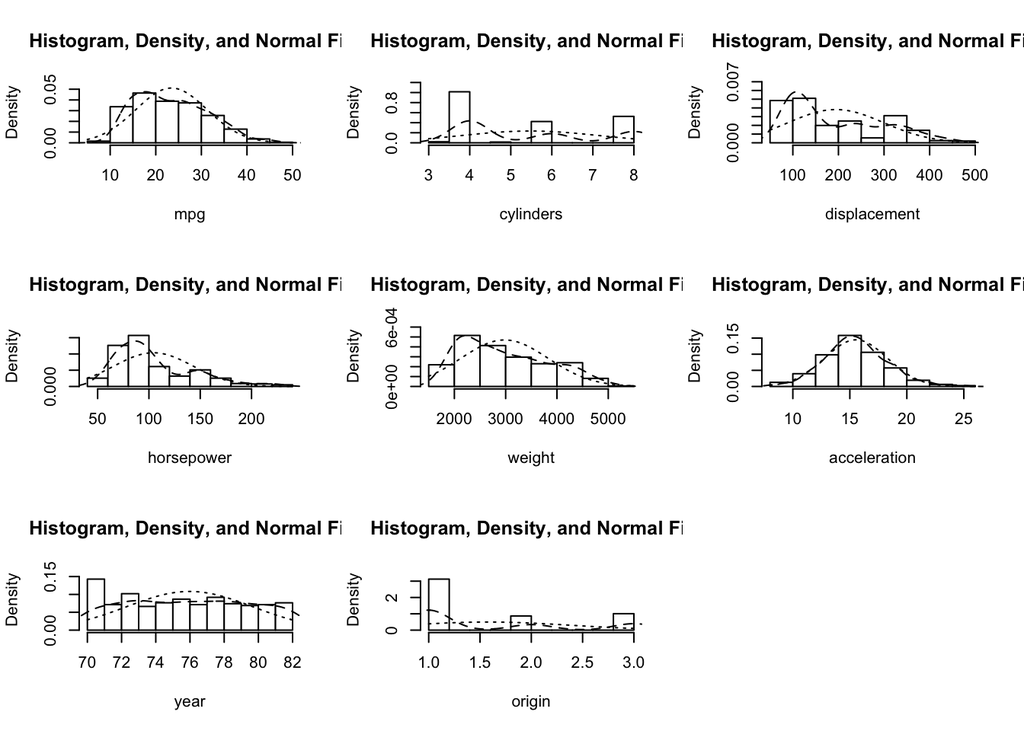

```r
multi.hist(exclude_names)
```

10. This question should be answered using the Carseats data set.

**(a) Fit a multiple regression model to predict Sales using Price, Urban, and US.**

```r
mdl <- lm(data=Carseats, Sales ~ Price + Urban + US); summary(mdl)
```

```
##
## Call:
## lm(formula = Sales ~ Price + Urban + US, data = Carseats)
##
## Residuals:
##     Min      1Q  Median      3Q     Max
## -6.9206 -1.6220 -0.0564  1.5786  7.0581
##
## Coefficients:
##              Estimate Std. Error t value Pr(>|t|)
## (Intercept) 13.043469   0.651012  20.036  < 2e-16 ***
## Price       -0.054459   0.005242 -10.389  < 2e-16 ***
## UrbanYes    -0.021916   0.271650  -0.081    0.936
## USYes        1.200573   0.259042   4.635 4.86e-06 ***
## ---
## Signif. codes:  0 '***' 0.001 '**' 0.01 '*' 0.05 '.' 0.1 ' ' 1
##
## Residual standard error: 2.472 on 396 degrees of freedom
## Multiple R-squared:  0.2393, Adjusted R-squared:  0.2335
## F-statistic: 41.52 on 3 and 396 DF,  p-value: < 2.2e-16
```

**(b) Provide an interpretation of each coefficient in the model. Be careful—some of the variables in the model are qualitative!**

There is a weak negative relationship (weak in magnitude, not in statistical signficance) between Sales and Price. Whether a store is located in an urban or rural area is not statistically significant. If a store is located in the US, it will have, on average, an increase of 1200 unit sales.

**(c) Write out the model in equation form, being careful to handle the qualitative variables properly.**

yhat = 13 + (price * -0.05) + (is urban ? -0.02 : 0) + (is US ? 1.2 : 0)

**(d) For which of the predictors can you reject the null hypothesis H0 :βj =0?**

**(e) On the basis of your response to the previous question, fit a smaller model that only uses the predictors for which there is evidence of association with the outcome.**

```r
nmdel <- lm(data=Carseats, Sales ~ Price + US) ; summary(nmdel)
```

```
##
## Call:
## lm(formula = Sales ~ Price + US, data = Carseats)
##
## Residuals:
##     Min      1Q  Median      3Q     Max
## -6.9269 -1.6286 -0.0574  1.5766  7.0515
##
## Coefficients:
##             Estimate Std. Error t value Pr(>|t|)
## (Intercept) 13.03079    0.63098  20.652  < 2e-16 ***
## Price       -0.05448    0.00523 -10.416  < 2e-16 ***
## USYes        1.19964    0.25846   4.641 4.71e-06 ***
## ---
## Signif. codes:  0 '***' 0.001 '**' 0.01 '*' 0.05 '.' 0.1 ' ' 1
##
## Residual standard error: 2.469 on 397 degrees of freedom
## Multiple R-squared:  0.2393, Adjusted R-squared:  0.2354
## F-statistic: 62.43 on 2 and 397 DF,  p-value: < 2.2e-16
```

**(f) How well do the models in (a) and (e) fit the data?**

The pruned model explains ~ 24% of the variability in the data, whereas the fatter model explains slightly less – though, in reality, since it includes an extra variable that is not considered statistically significant, it is probably not fair to say that it performs better.

**(g) Using the model from (e), obtain 95% confidence intervals for the coefficient(s).**

```r
confint(nmdel)
```

```
##                   2.5 %      97.5 %
## (Intercept) 11.79032020 14.27126531
## Price       -0.06475984 -0.04419543
## USYes        0.69151957  1.70776632
```

**(h) Is there evidence of outliers or high leverage observations in the model from (e)?**

11. In this problem we will investigate the t-statistic for the null hypothesis H0 : β = 0 in simple linear regression without an intercept. To begin, we generate a predictor x and a response y as follows.

```r
set.seed(1)
x = rnorm(100)
y = 2*x+rnorm(100)
```

Perform a simple linear regression of y onto x, without an intercept.

```r
slopeFinder <- function(vector_x, vector_y) {
  xbar = mean(vector_x);
  ybar = mean(vector_y);

  # is this element-wise multiplication?
  xdiff = vector_x - xbar;
  numerator = sum(xdiff * (vector_y - ybar))
  denom = sum(xdiff ^ 2)

  return(numerator / denom)

}
slopeFinder(x, y)
```

```
## [1] 1.99894
```

```r
mdl = lm(y ~ x + 0); summary(mdl)
```

```
##
## Call:
## lm(formula = y ~ x + 0)
##
## Residuals:
##     Min      1Q  Median      3Q     Max
## -1.9154 -0.6472 -0.1771  0.5056  2.3109
##
## Coefficients:
##   Estimate Std. Error t value Pr(>|t|)
## x   1.9939     0.1065   18.73   <2e-16 ***
## ---
## Signif. codes:  0 '***' 0.001 '**' 0.01 '*' 0.05 '.' 0.1 ' ' 1
##
## Residual standard error: 0.9586 on 99 degrees of freedom
## Multiple R-squared:  0.7798, Adjusted R-squared:  0.7776
## F-statistic: 350.7 on 1 and 99 DF,  p-value: < 2.2e-16
```

Report the coefficient estimate βˆ, the standard error of this coefficient estimate, and the t-statistic and p-value associ- ated with the null hypothesis H0 : β = 0. Comment on these results.

The estimate appears to be highly correlated with the response value, with a low p value and a high t-value. There is a positive slope of ~2.

**b) Now perform a simple linear regression of x onto y without an intercept, and report the coefficient estimate, its standard error, and the corresponding t-statistic and p-values associated with the null hypothesis H0 : β = 0. Comment on these results.**

```r
xmdl <- lm(x ~ y + 0) ; summary(xmdl)
```

```
##
## Call:
## lm(formula = x ~ y + 0)
##
## Residuals:
##     Min      1Q  Median      3Q     Max
## -0.8699 -0.2368  0.1030  0.2858  0.8938
##
## Coefficients:
##   Estimate Std. Error t value Pr(>|t|)
## y  0.39111    0.02089   18.73   <2e-16 ***
## ---
## Signif. codes:  0 '***' 0.001 '**' 0.01 '*' 0.05 '.' 0.1 ' ' 1
##
## Residual standard error: 0.4246 on 99 degrees of freedom
## Multiple R-squared:  0.7798, Adjusted R-squared:  0.7776
## F-statistic: 350.7 on 1 and 99 DF,  p-value: < 2.2e-16
```

Again, we find statistical signficance.

**(c) What is the relationship between the results obtained in (a) and (b)?**

The t-values, and thus the p-values are the same.